# Assignment 1 Chengdong

Chengdong Liang

February 11, 2017

## 1 Introduction

## 2 Goals

## 3 Dataset Description

## 4 Objectives

## 5 Dataset Preparation

### 5.1 Libraries used

#### 5.1.1 “dplyr” package

We will load the *‘dplyr’* package that contains functions for data manipulation using data frames. It allows us to order rows, select rows, select variables, modify variables and summarize variables.

```r
library(dplyr)
```

#### 5.1.2 “ggplot2” package

We will load the *“ggplot2”* package which is a powerful plotting system that creates elegant and complex plots in R.

```r
library(ggplot2)
```

#### 5.1.3 “ggvis” package

We will also use the graphics commands from the ggvis library.

```r
library(ggvis)
```

#### 5.1.4 “magrittr” package

The magrittr library is loaded for the piping operator %>%.

```r
library(magrittr)
```

```r
library(readr)
csb.df = read_csv(paste0('C:/Users/Chengdong Liang/Desktop/MA 710/Assignment 1/CollegeScorecard_Raw_Data/', 'MERGED2014_15_PP.csv'))
csb.df %>%
  select(CONTROL, CDR3, CDR3_DENOM, PCTPELL, PCTFLOAN, DEBT_N, CUML_DEBT_N) %>%
  {.} -> csb.vars.df
```

### 5.2 Varible Modification

#### 5.2.1 Select Variables

Firstly we take a look at varibles that we are interested:

| Varible | Type | Description |
| --- | --- | --- |
| CONTROL | Factor | Control of institution |
| CDR3 | Numeric | Three-year cohort default rate |
| CDR3_DENOM | Numeric | Number of students in the cohort for the three-year cohort default rate |
| PCTPELL | Numeric | Percentage of undergraduates who receive a Pell Grant |
| PCTFLOAN | Numeric | Percent of all federal undergraduate students receiving a federal student loan |
| DEBT_N | Numeric | The number of students in the median debt completers cohort |
| CUML_DEBT_N | Numeric | Number of students in the cumulative loan debt cohort |

#### 5.2.2 Convert class of variables

Then we need to datatype of all selected variables class and conver them into proper way:

```r
str(csb.vars.df)
```

[output not shown]

[output cut: 162 more lines]

[output not shown]

```r
csb.vars.df %>%
  mutate(CONTROL  = as.factor(CONTROL),
         CDR3 = as.numeric(CDR3),
         CDR3_DENOM  = as.numeric(CDR3_DENOM),
         PCTPELL = as.numeric(PCTPELL),
         PCTFLOAN = as.numeric(PCTFLOAN),
         DEBT_N = as.numeric(DEBT_N),
         CUML_DEBT_N = as.numeric(CUML_DEBT_N)
         )%>%
         {.} -> csb.vars.df
```

For the target varible “CONTROL”, we need to convert it into a factor varible with two levels: Level=1 stands for public; Level= 0 stands for Private

```r
csb.vars.df %>%
  mutate(CONTROL = ifelse((CONTROL==2|CONTROL==3),0,1)) %>%
  mutate(CONTROL = as.factor(CONTROL)) %>%
  {.} ->csb.vars.df
```

#### 5.2.3 Check missing values

We need to check for the percentage of missing values of all selected varibles:

```r
csb.vars.df %>%
  summarise_at(.cols = vars(),
               .funs = function(x) sum(is.na(x))/length(x))*100
```

```
##   CONTROL     CDR3 CDR3_DENOM  PCTPELL PCTFLOAN   DEBT_N CUML_DEBT_N
## 1       0 13.74789   13.74789 9.567701 9.567701 11.98234    11.98234
```

*CDR3 and CDR3_DENOM have the highest percentage of missing value: 13.74789%

*CONTROL has no NA value

*All variables are clean enough in terms of missing value. There is no need to deal with missing values.

## 6 Variable Summaries

To get a better understanding of our variables, we could adopt descriptive analysis to summary independent varibles. Furthermore, we could generate summary statistics respectively for two different categories of our target varivble- CONTROL:

```r
options(dplyr.width=Inf)
csb.vars.df %>%
  group_by (CONTROL) %>%
  summarise_if(is.numeric, funs(mean, median, var), na.rm=TRUE)
```

```
## # A tibble: 2 × 19
##   CONTROL CDR3_mean CDR3_DENOM_mean PCTPELL_mean PCTFLOAN_mean DEBT_N_mean
##    <fctr>     <dbl>           <dbl>        <dbl>         <dbl>       <dbl>
## 1       0 0.1198213        6193.044    0.5759460     0.6025042    7275.904
## 2       1 0.1361324        2498.717    0.4207212     0.3214138    4193.410
##   CUML_DEBT_N_mean CDR3_median CDR3_DENOM_median PCTPELL_median
##              <dbl>       <dbl>             <dbl>          <dbl>
## 1         7275.904       0.114               462         0.6007
## 2         4193.410       0.131              1030         0.4047
##   PCTFLOAN_median DEBT_N_median CUML_DEBT_N_median    CDR3_var
##             <dbl>         <dbl>              <dbl>       <dbl>
## 1         0.65745         738.5              738.5 0.005920660
## 2         0.31225        1914.5             1914.5 0.005892663
##   CDR3_DENOM_var PCTPELL_var PCTFLOAN_var DEBT_N_var CUML_DEBT_N_var
##            <dbl>       <dbl>        <dbl>      <dbl>           <dbl>
## 1      465642837  0.05298539   0.06421078  572772521       572772521
## 2       21971425  0.02886076   0.06593408   46709416        46709416
```

In conclusion, the summary statistics reveals that considerably differnece exists between two catories of target varible.

## 7 Variable relationships

### 7.1 Target variable ‘CONTROL’

We use a bar plot to compare numbers of observations for the target variable *CONTROL*

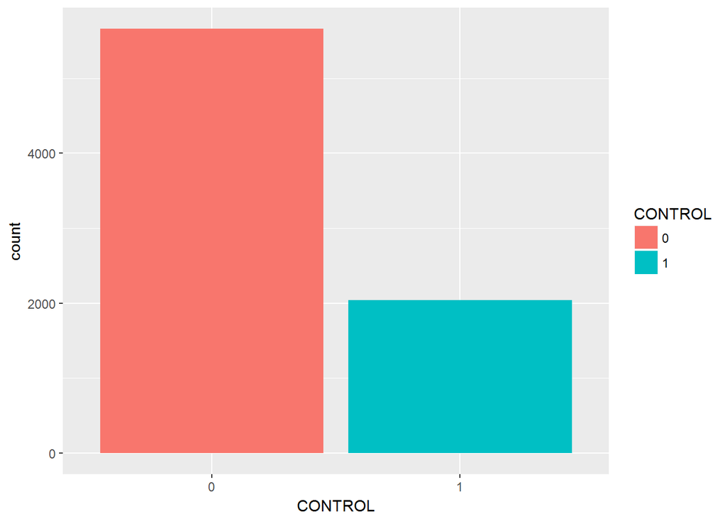

```r
csb.vars.df %>%
  ggplot  (aes(x   =CONTROL)) +
  geom_bar(aes(fill=CONTROL))
```

From the plot above we can find that there are appriximately 2,000 Public insitituions. The number of Private colleges is nearly 5700.

### 7.2 Target variable ~ independent variables

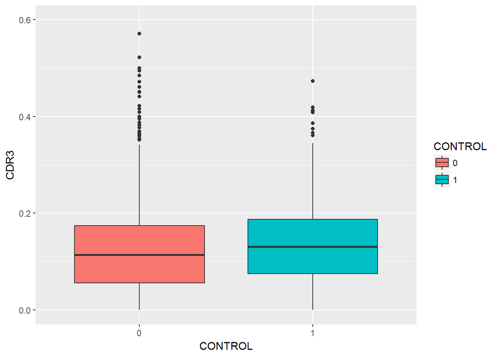

```r
csb.vars.df %>%
  ggplot(aes(x=CONTROL,
             y=CDR3)) +
  geom_boxplot(aes(fill=CONTROL)) +
    ylim(0, 0.6)
```

### 7.2.2 “CONTROL”~“CDR3_DENOM”

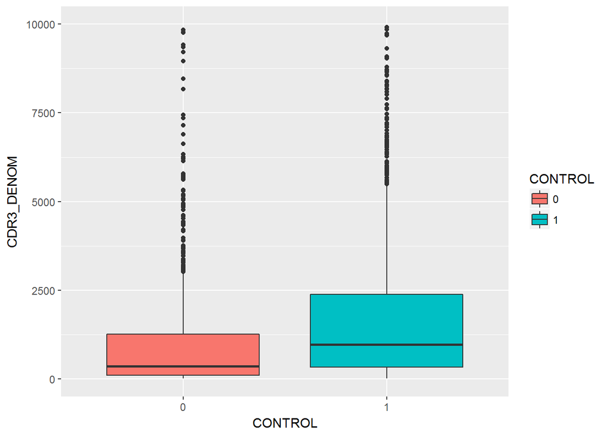

```r
csb.vars.df %>%
  ggplot(aes(x=CONTROL,
             y=CDR3_DENOM)) +
  geom_boxplot(aes(fill=CONTROL)) +
  ylim(0, 10000)
```

### 7.2.3 “CONTROL”~“PCTPELL”

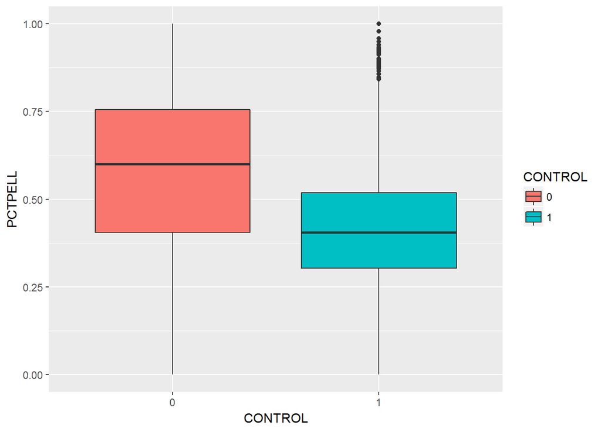

```r
csb.vars.df %>%
  ggplot(aes(x=CONTROL,
             y=PCTPELL)) +
  geom_boxplot(aes(fill=CONTROL))
```

### 7.2.4 “CONTROL”~“PCTFLOAN”

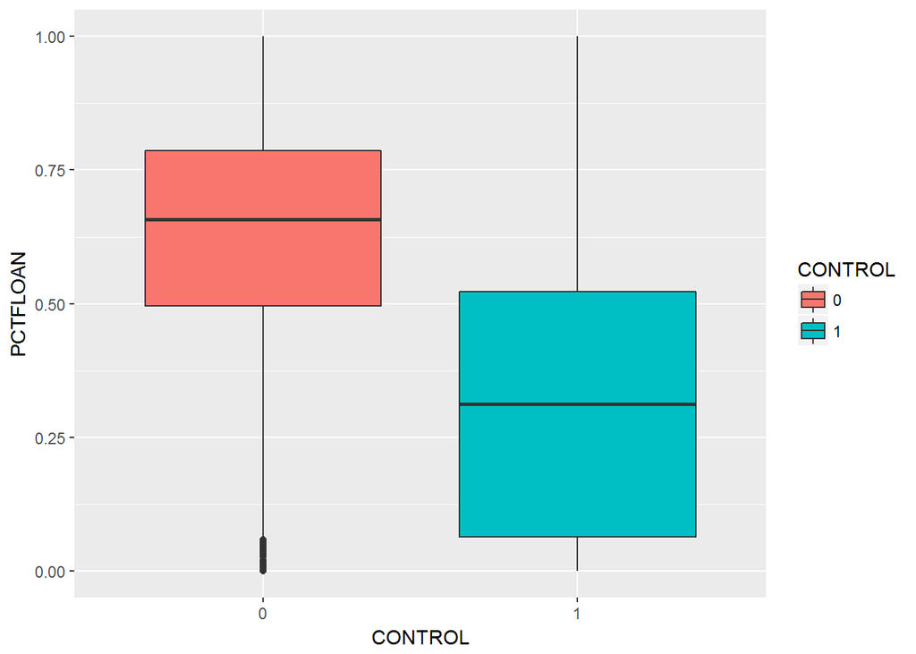

```r
csb.vars.df %>%
  ggplot(aes(x=CONTROL,
             y=PCTFLOAN)) +
  geom_boxplot(aes(fill=CONTROL))
```

### 7.2.5 “CONTROL”~“DEBT_N”

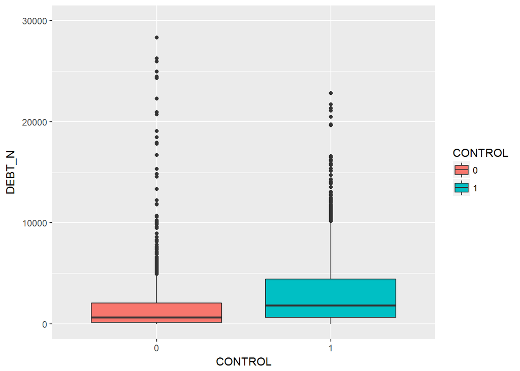

```r
csb.vars.df %>%
  ggplot(aes(x=CONTROL,
             y=DEBT_N)) +
  geom_boxplot(aes(fill=CONTROL)) +
  ylim(0, 30000)
```

### 7.2.6 “CONTROL”~“CUML_DEBT_N”

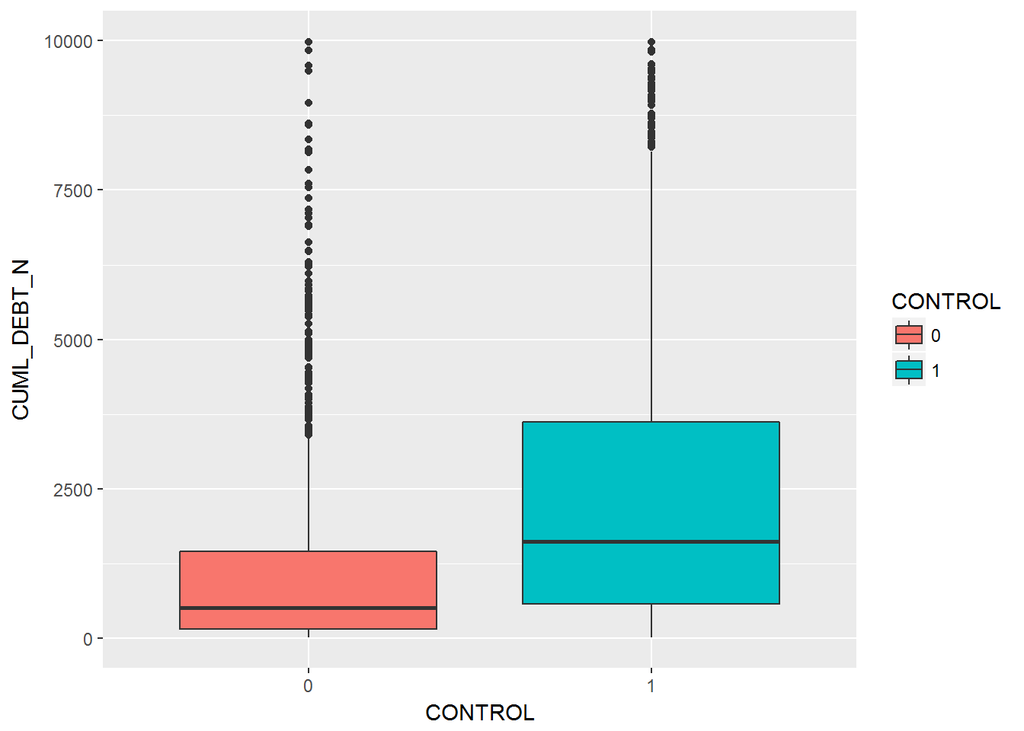

```r
csb.vars.df %>%
  ggplot(aes(x=CONTROL,
             y=CUML_DEBT_N)) +
  geom_boxplot(aes(fill=CONTROL)) +
  ylim(0, 10000)
```

From all the box-plot above, we could conclude that the distribution of each variable are quite different for two levels of the target varible. We could draw the conclusion and achieve our initial goal based on our analysis output.